# Econometria Aplicada à Finanças Aula 3

Mestrado Profissional em Administração

Prof. Dr. Washington S. da Silva

IFMG — Campus Formiga

18 de agosto de 2026

Abertura

## Programação da aula

### Aula anterior

Os principais tópicos efetivamente abordados na Aula 2 foram:

- Linearidade nos parâmetros e formas funcionais.
- Regressão múltipla: interpretação *ceteris paribus*, teorema de Frisch–Waugh–Lovell e medidas de ajuste.
- Viés de variável omitida.
- Interpretação de coeficientes: variáveis categóricas, interações e especificações com logaritmos e implementação em R.

### Hoje

Heterocedasticidade

Heterocedasticidade

## Heterocedasticidade

Vamos enunciar nossas **hipóteses atuais**:

1. Nossa amostra (os $x_k$ e $y_i$) foi selecionada aleatoriamente da população.
2. $y$ é uma função linear dos parâmetros $\beta_k$ e de $\varepsilon_i$.
3. Não há multicolinearidade perfeita em nossa amostra.
4. As variáveis explicativas são exógenas: $\mathop{\boldsymbol{E}}\left[ \varepsilon_i \middle| X \right] = 0 \left(\implies \mathop{\boldsymbol{E}}\left[ \varepsilon_i \right] = 0\right)$.
5. Os erros têm variância constante $\sigma^2$ e covariância zero, isto é,
   - $\mathop{\boldsymbol{E}}\left[ \varepsilon_i^2 \middle| X \right] = \mathop{\text{Var}} \left( \varepsilon_i \middle| X \right) = \sigma^2$
   - $\mathop{\text{Cov}} \left( \varepsilon_i, \, \varepsilon_j \middle| X \right) = \mathop{\boldsymbol{E}}\left[ \varepsilon_i \varepsilon_j \middle| X \right] = 0$ para $i\neq j$
6. Os erros seguem uma distribuição Normal, isto é, $\varepsilon_i \overset{\text{iid}}{\sim} \mathop{\text{N}}\left( 0, \sigma^2 \right)$.

## Heterocedasticidade

Hoje nos concentraremos na hipótese #5:

5. Os erros têm variância constante $\sigma^2$ e covariância zero, isto é,

- $\mathop{\boldsymbol{E}}\left[ \varepsilon_i^2 \middle| X \right] = \mathop{\text{Var}} \left( \varepsilon_i \middle| X \right) = \sigma^2$
- $\mathop{\text{Cov}} \left( \varepsilon_i, \, \varepsilon_j \middle| X \right) = \mathop{\boldsymbol{E}}\left[ \varepsilon_i \varepsilon_j \middle| X \right] = 0$ para $i\neq j$

Vamos nos concentrar na hipótese de variância constante  
(também conhecida como *homocedasticidade*).

**Violação dessa hipótese:**

Heterocedasticidade: $\mathop{\text{Var}} \left( \varepsilon_i \middle| X \right) = \sigma_i^2$, com $\sigma_i^2$ variando sistematicamente com $X$.

Em outras palavras: a dispersão dos erros muda conforme os valores das variáveis explicativas.

## Heterocedasticidade

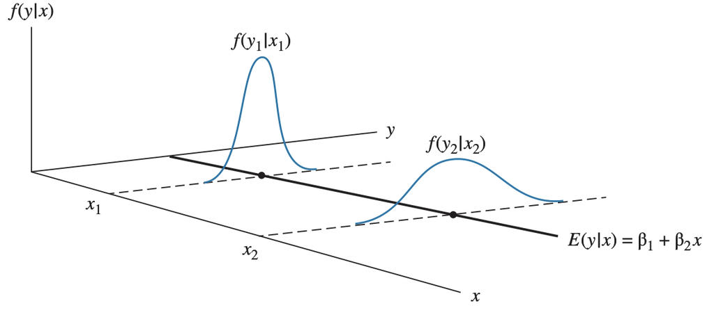

Em $x_2$, $f(y\mid x)$ é mais dispersa em torno de $E(y\mid x)$: a variância dos erros aumenta com $x$. Sob homocedasticidade, essa dispersão seria constante.

## Heterocedasticidade

Exemplo clássico de heterocedasticidade: o funil

A variância condicional de $\varepsilon_i$ aumenta com $x$

[figure not shown]

## Heterocedasticidade

Outro exemplo de heterocedasticidade: funil duplo

A variância condicional de $\varepsilon_i$ aumenta nos extremos de $x$

[figure not shown]

## Heterocedasticidade

Outro exemplo de heterocedasticidade:

Variâncias condicionais de $\varepsilon_i$ diferentes entre grupos

[figure not shown]

## Heterocedasticidade

### O que é e por quê?

Há heterocedasticidade quando $\mathop{\mathrm{Var}}(\varepsilon_i\mid X)=\sigma_i^2$ varia sistematicamente com alguma combinação das variáveis explicativas $x_1$ a $x_k$.

Ela é muito comum na prática e provavelmente deveria ser nosso caso de referência.

Por que isso importa: a heterocedasticidade mostra como pequenas violações de nossas hipóteses podem afetar o desempenho de MQO.

## Heterocedasticidade

### Consequências: viés

Na regressão simples, podemos escrever

$$\hat{\beta}_1 = \beta_1 + \frac{\sum_i (x_i-\bar{x})\varepsilon_i}{\sum_i (x_i-\bar{x})^2}.$$

Sob exogeneidade, a esperança condicional do estimador é

$$\mathop{\boldsymbol{E}}(\hat{\beta}_1\mid X)
=\beta_1+\frac{\sum_i (x_i-\bar{x})\mathop{\boldsymbol{E}}(\varepsilon_i\mid X)}{\sum_i (x_i-\bar{x})^2}
=\beta_1.$$

A heterocedasticidade altera $\mathop{\mathrm{Var}}(\varepsilon_i\mid X)$, mas não elimina $\mathop{\boldsymbol{E}}(\varepsilon_i\mid X)=0$. Sob exogeneidade, o estimador de MQO continua não viesado.

A **eficiência** de MQO e a **inferência** convencional não sobrevivem à heterocedasticidade.

## Heterocedasticidade

### Consequências: eficiência

Na presença de heterocedasticidade, MQO deixa de ser o estimador linear não viesado mais eficiente.

Seria mais informativo (eficiente) ponderar as observações pelo inverso da variância de seus $\varepsilon_i$.

- Atribuir menor peso aos $\varepsilon_i$ de alta variância (ruidosos demais para fornecer muita informação).
- Atribuir maior peso às observações com $\varepsilon_i$ de baixa variância (mais “confiáveis”).
- Essa é a ideia dos mínimos quadrados ponderados (MQP).

## Heterocedasticidade

### Consequências: inferência

Na presença de heterocedasticidade, os erros-padrão convencionais de MQO são viesados.

- Intervalos de confiança incorretos.
- Problemas nos testes de hipóteses (tanto nos testes $t$ quanto nos testes $F$).
- É difícil aprender sem inferência confiável.

## Heterocedasticidade

### Diagnóstico e respostas são etapas distintas

- **Diagnóstico:** gráficos e testes investigam se a variância condicional apresenta padrões sistemáticos.
- **Inferência:** erros-padrão robustos permitem inferência assintoticamente válida sem alterar os coeficientes de MQO.
- **Eficiência:** se houver uma estrutura justificável para a variância, métodos ponderados podem aproveitar essa informação.

Um teste não “corrige” a heterocedasticidade nem funciona como autorização automática para usar — ou deixar de usar — inferência robusta.

Lógica dos testes de heterocedasticidade

## Lógica dos testes de heterocedasticidade

### O ponto de partida: um padrão que $\text{H}_0$ não explica

Nos testes de heterocedasticidade, começamos pelo modelo sob a hipótese de variância constante:

$$\text{H}_0:\mathop{\mathrm{Var}}\left(\varepsilon_i\mid X\right)=\sigma^2.$$

Após estimar o modelo por MQO, os resíduos ao quadrado podem revelar padrões incompatíveis com $\text{H}_0$.

Se variáveis que descrevem a observação explicam sistematicamente $\hat{\varepsilon}_i^2$, a hipótese de variância constante torna-se menos compatível com os dados.

Breusch–Pagan/Koenker e White transformam essa ideia em estatísticas de teste.

## Lógica dos testes de heterocedasticidade

### O LM avalia o modelo restrito

Se $\text{H}_0$ impõe $\theta=c$, então $c$ representa o valor — ou o vetor de valores — fixado pela hipótese nula. O **escore** é a inclinação da log-verossimilhança:

$$s(\theta)=\frac{\partial\ell(\theta)}{\partial\theta}.$$

O teste LM avalia $s(c)$ no modelo restrito. Se esse escore estiver distante de zero, relaxar a restrição pode melhorar o ajuste local.

A informação de Fisher calibra o tamanho do escore:

$$\text{LM}=s(c)^\top I(c)^{-1}s(c).$$

A vantagem operacional é que o LM não exige estimar o modelo irrestrito.

<sup>1</sup>

[^1]: Fonte: Hill, Griffiths e Lim (2018), apêndice C.8.4.

## Lógica dos testes de heterocedasticidade

### Do princípio LM à regressão auxiliar

1. Estimamos o modelo original por MQO e obtemos $\hat{\varepsilon}_i$.
2. Regridimos $\hat{\varepsilon}_i^2$ em variáveis candidatas a descrever sua variância.
3. Testamos conjuntamente se essas variáveis explicam os resíduos ao quadrado.

$$\text{H}_0:\alpha_1=\alpha_2=\cdots=\alpha_J=0.$$

Na versão studentizada de Koenker e no teste de White, a forma operacional é

$$\text{LM}=nR^2_{\hat{\varepsilon}^2}
\qquad\text{e, sob }\text{H}_0,\qquad
\text{LM}\overset{\text{d}}{\longrightarrow}\chi_J^2.$$

Essa é uma aplicação do princípio LM; não é a estatística original de Breusch–Pagan.

$J$ é o número de coeficientes testados conjuntamente, excluindo o intercepto.

## Lógica dos testes de heterocedasticidade

### A decisão ocorre na cauda direita

Sob $\text{H}_0$, a estatística LM segue assintoticamente uma distribuição $\chi_J^2$; neste exemplo, $J=2$.

A área destacada é o valor-*p*: a probabilidade, sob $\text{H}_0$, de observar um valor de LM igual ou superior ao calculado.

[figure not shown]

Testes de heterocedasticidade

## Testes de heterocedasticidade

Os testes a seguir usam os resíduos de MQO para investigar padrões distintos na variância condicional. Eles são instrumentos de diagnóstico, não correções.

1. O **teste de Goldfeld–Quandt**
2. O **teste de Breusch–Pagan/Koenker**
3. O **teste de White**

A sequência também mostra uma evolução: de uma alternativa fortemente estruturada para regressões auxiliares mais flexíveis.

## Testes de heterocedasticidade

### O teste de Goldfeld–Quandt

O teste de Goldfeld–Quandt é dirigido a uma forma específica de heterocedasticidade: a variância muda quando as observações são ordenadas por uma variável *z*.<sup>1</sup>

1. Ordene as observações por *z*.
2. Forme dois grupos, omitindo observações centrais.
3. Estime a regressão original separadamente em cada grupo.
4. Compare as variâncias residuais dos dois grupos.

O procedimento é informativo quando existe uma justificativa para a ordenação e para a direção esperada da mudança na variância.

[^2]: Ver Goldfeld e Quandt (1965).

## Testes de heterocedasticidade

### O teste de Goldfeld–Quandt

A estatística compara as variâncias residuais:

$$F = \frac{\text{SSE}_2/(n_2-k)}{\text{SSE}_1/(n_1-k)}
\quad\overset{\text{H}_0}{\sim}\quad
F_{n_2-k,\,n_1-k}.$$

Essa distribuição sob $\text{H}_0\!:\sigma_1^2=\sigma_2^2$ exige normalidade dos erros. O termo $k$ representa o número de parâmetros estimados em cada regressão.

Quando a alternativa prevê maior variância no segundo grupo, valores elevados de $F$ levam à rejeição na cauda direita.

## Testes de heterocedasticidade

### Goldfeld–Quandt: caso do funil

[figure not shown]

$F_{373,\,373} \approx 5.62$ e valor-*p* $< 0{,}001$.

Neste funil, a dispersão aumenta com $x$. A razão entre as variâncias residuais fornece evidências contra $\text{H}_0\!:\sigma_1^2=\sigma_2^2$.

## Testes de heterocedasticidade

### Goldfeld–Quandt depende da ordenação escolhida

[figure not shown]

$F_{373,\,373} \approx 0.97$ e valor-*p* $\approx 0.609$.

As duas caudas apresentam dispersões semelhantes. Por isso, o teste pode não rejeitar $\text{H}_0$, embora a variância dependa de $x^2$.

## Testes de heterocedasticidade

### Breusch–Pagan usa uma regressão auxiliar

A variância pode ser relacionada a $J$ variáveis $z_1,\ldots,z_J$ por meio da regressão auxiliar

$$\hat{\varepsilon}_i^2 = \alpha_0 + \alpha_1 z_{1i} + \cdots + \alpha_J z_{Ji} + v_i.$$

No uso mais comum, as variáveis $z_j$ são as regressoras do modelo original.

$$\text{H}_0:\alpha_1=\cdots=\alpha_J=0$$

Sob $\text{H}_0$, nenhuma dessas variáveis explica sistematicamente a variância dos erros.

## Testes de heterocedasticidade

### A versão de Koenker produz $LM=nR^2$

Na versão studentizada associada a Koenker (1981),

$$\text{LM}=nR^2_{\hat{\varepsilon}^2}
\qquad\text{e}\qquad
\text{LM}\overset{\mathrm{d}}{\longrightarrow}\chi_J^2.$$

```r
# Executa a versão studentizada de Koenker
lmtest::bptest(modelo)
```

Por padrão, `bptest()` usa `studentize = TRUE`. O teste original de Breusch–Pagan é obtido com `studentize = FALSE`.<sup>1</sup>

[^3]: Ver Breusch e Pagan (1979) e Koenker (1981), *A Note on Studentizing a Test for Heteroscedasticity*, *Journal of Econometrics*, 17, 107–112.

## Testes de heterocedasticidade

### White amplia a regressão auxiliar

Breusch–Pagan/Koenker detecta as relações entre $\hat{\varepsilon}_i^2$ e as variáveis $z_j$ incluídas na regressão auxiliar.

- Quando usamos somente as regressoras originais, investigamos uma especificação linear para a variância.
- Uma forma não linear omitida pode passar despercebida.

**White (1980)** amplia a regressão auxiliar com termos quadráticos e interações entre as regressoras, tornando o teste mais flexível.<sup>1</sup>

[^4]: Ver White (1980).

## Testes de heterocedasticidade

### O teste de White

O teste de White utiliza uma condição implicada pela homocedasticidade, mas mais fraca do que ela:

- **Homocedasticidade:** $\mathop{\text{Var}} \left( \varepsilon_i \middle| X \right) = \sigma^2$.
- **Condição testada:** $\varepsilon_i^2$ não apresenta correlação com as variáveis explicativas, seus quadrados e as interações de primeira ordem.

Essa condição pode ser examinada por uma regressão auxiliar. Condicionalmente à especificação correta da média, rejeitá-la fornece evidências de heterocedasticidade. Caso contrário, a rejeição também pode refletir erro de especificação.

Não rejeitar $\text{H}_0$ não demonstra homocedasticidade contra todas as formas possíveis.

## Testes de heterocedasticidade

### O teste de White

Esquema do teste de White para heterocedasticidade:

$$\hat{\varepsilon}_i^2 = \alpha_0 + \sum_{h=1}^k \alpha_h x_h + \sum_{j=1}^k \alpha_{k+j} x_j^2 + \sum_{\ell = 1}^{k-1} \sum_{m = \ell + 1}^k \alpha_{\ell,m} x_\ell x_m + v_i$$

3. Registre $R^2_{\hat{\varepsilon}^2}$.

4. Teste H0: $\alpha_1=\cdots=\alpha_J=0$ com

$$\text{LM}=nR^2_{\hat{\varepsilon}^2}
\qquad\text{e, sob }\text{H}_0,\qquad
\text{LM}\overset{\mathrm{d}}{\longrightarrow}\chi_J^2.$$

$J$ é o número de coeficientes testados conjuntamente, excluindo o intercepto.

## Testes de heterocedasticidade

### O teste de White

[figure not shown]

O teste de White para esta regressão linear simples.

$$\begin{aligned}
\hat{\varepsilon}_i^2 &= \hat{\alpha}_0 + \hat{\alpha}_1 x_{1i} \textcolor{#e64173}{+ \hat{\alpha}_2 x^2_{1i}} & \text{LM} &= 185.8 &\text{valor-}p < 0.001
\end{aligned}$$

Testes de heterocedasticidade

Exemplos

## Testes de heterocedasticidade

### Exemplos

**Objetivo:** estimar a relação entre as notas padronizadas nos testes (variável dependente), (1) a relação alunos-professor e (2) a renda, isto é,

$$\left(\text{Nota no teste}\right)_i = \beta_0 + \beta_1 \text{Relação}_{i} + \beta_2 \text{Renda}_{i} + \varepsilon_i \tag{1}$$

**Possível problema:** heterocedasticidade — e não observamos $\varepsilon_i$.

**Estratégia de diagnóstico:**

1. Estime a relação em $(1)$ usando MQO.
2. Examine o comportamento dos resíduos.
3. Compare os testes de Breusch–Pagan/Koenker e de White.

## Testes de heterocedasticidade

### Exemplos

Usaremos dados de desempenho escolar da base `Caschool`, disponível no pacote `Ecdat` do R.

```r
# Seleciona e renomeia as variáveis; atribui o resultado a uma nova base
test_df = dplyr::select(
  Ecdat::Caschool,
  test_score = testscr,
  ratio = str,
  income = avginc
)
# Converte para tibble
test_df = tibble::as_tibble(test_df)
# Exibe as duas primeiras linhas da base
head(test_df, 2)
```

```
#> # A tibble: 2 × 3
#>   test_score ratio income
#>        <dbl> <dbl>  <dbl>
#> 1       691.  17.9  22.7
#> 2       661.  21.5   9.82
```

## Testes de heterocedasticidade

### Exemplos

Vamos começar estimando nosso modelo:

$$\left(\text{Nota no teste}\right)_i = \beta_0 + \beta_1 \text{Relação}_{i} + \beta_2 \text{Renda}_{i} + \varepsilon_i$$

```r
# Estima o modelo
est_model = lm(test_score ~ ratio + income, data = test_df)
# Resume as estimativas
broom::tidy(est_model)
```

```
#> # A tibble: 3 × 5
#>   term        estimate std.error statistic   p.value
#>   <chr>          <dbl>     <dbl>     <dbl>     <dbl>
#> 1 (Intercept)  639.       7.45       85.7  5.70e-267
#> 2 ratio         -0.649    0.354      -1.83 6.79e-  2
#> 3 income         1.84     0.0928     19.8  4.38e- 62
```

## Testes de heterocedasticidade

### Diagnóstico visual: `Residuals vs Fitted`

O gráfico representa os resíduos no eixo vertical e os valores ajustados no eixo horizontal.

```r
# Adiciona os resíduos à base de dados
test_df$residuo = residuals(est_model)

# Seleciona o gráfico Residuals vs Fitted
plot(est_model, which = 1)
```

[figure not shown]

Procuramos resíduos centrados em zero e dispersão vertical aproximadamente constante. Mudanças de largura sugerem heterocedasticidade; curvatura na linha vermelha pode indicar especificação inadequada da média. O gráfico é diagnóstico, não um teste formal.

## Testes de heterocedasticidade

### Exemplo: Breusch–Pagan/Koenker

O teste studentizado verifica se as regressoras originais explicam a variância dos erros.

```r
# Executa a versão studentizada de Koenker
resultado_bp <- lmtest::bptest(est_model)

# Exibe a estatística LM, os graus de liberdade e o valor-p
resultado_bp
```

```
#>
#>  studentized Breusch-Pagan test
#>
#> data:  est_model
#> BP = 0.013575, df = 2, p-value = 0.9932
```

O resultado não fornece evidências de uma relação **linear** entre a variância e as regressoras. Isso não exclui outras formas de heterocedasticidade — exatamente o que o teste de White investigará em seguida.

## Heterocedasticidade

### Exemplo: White

Para o mesmo modelo, White acrescenta termos quadráticos e a interação à regressão auxiliar:
$$\begin{align}
\textcolor{#314f4f}{\hat{\varepsilon}_i^2} =& \textcolor{#314f4f}{\alpha_{0} + \alpha_{1} \text{Relação}_{i} + \alpha_{2} \text{Renda}_{i} } \\
&+ \textcolor{#e64173}{\alpha_{3} \text{Relação}_{i}^2 + \alpha_{4} \text{Renda}_{i}^2 + \alpha_{5} \text{Relação}_{i}\times\text{Renda}_{i}} \\
&+ \textcolor{#314f4f}{w_{i}}
\end{align}$$

Testamos conjuntamente

$$\text{H}_0:\alpha_1=\alpha_2=\alpha_3=\alpha_4=\alpha_5=0.$$

Rejeitar essas restrições indica que o modelo sob $\text{H}_0$ não explica o padrão dos resíduos ao quadrado. Isso é compatível com heterocedasticidade, mas também pode decorrer de uma média condicional mal especificada.

## Heterocedasticidade

### Exemplo: White em um único bloco

Em `lm()`, `I(x^2)` calcula o quadrado de uma variável e `x1:x2` inclui sua interação.

```r
# Estima a regressão auxiliar com termos lineares, quadráticos e interação
white_model = lm(
  I(residuo^2) ~ ratio + income + I(ratio^2) + I(income^2) + ratio:income,
  data = test_df
)

# Extrai o R-quadrado e calcula a estatística LM
white_r2 = summary(white_model)$r.squared
white_stat = nrow(test_df) * white_r2

# Calcula o valor-p para as cinco restrições conjuntas
white_p = pchisq(white_stat, df = 5, lower.tail = FALSE)

# Exibe a estatística e o valor-p
c(LM = white_stat, valor_p = white_p)
```

```
#>           LM      valor_p
#> 3.079533e+01 1.028039e-05
```

## Heterocedasticidade

### Exemplo: White

Como $J=5$ coeficientes são testados conjuntamente,

$$\text{LM}=nR^2_{\hat{\varepsilon}^2}
=420\times 0.073
\approx 30.8,
\qquad \text{LM}\overset{\mathrm{d}}{\longrightarrow}\chi_5^2.$$

O valor-*p* é menor que 0,001; portanto, rejeitamos $\text{H}_0$ ao nível de 5%.

**Conclusão:** os resíduos ao quadrado apresentam um padrão explicado pelos termos da regressão auxiliar. O resultado é compatível com heterocedasticidade, mas, em dados empíricos, também pode sinalizar especificação inadequada da média condicional.

## Heterocedasticidade

### Questões para revisão

- **P:** Qual é a definição de heterocedasticidade?
- **P:** Por que a heterocedasticidade nos preocupa?
- **P:** O que `Residuals vs Fitted` pode — e não pode — indicar?
- **P:** Quando Breusch–Pagan/Koenker e White podem levar a conclusões diferentes?

## Heterocedasticidade

### Revisão: definição e consequências

- **P:** Qual é a definição de heterocedasticidade?
- **R:**  
  Em termos matemáticos: $\mathop{\mathrm{Var}}(\varepsilon_i\mid X)=\sigma_i^2$, com $\sigma_i^2$ variando sistematicamente com $X$.  
  Em palavras: a dispersão condicional dos erros não permanece constante.
- **P:** Por que isso importa?
- **R:** Sob exogeneidade, o estimador de MQO continua não viesado, mas perde eficiência e os erros-padrão convencionais deixam de sustentar inferência confiável.

## Heterocedasticidade

### Revisão: diagnóstico e escolha do teste

- **Residuals vs Fitted:** mudanças sistemáticas na dispersão vertical sugerem heterocedasticidade; curvatura na média pode indicar erro de especificação. O gráfico não prova nenhuma das duas conclusões.
- **Testes:** Breusch–Pagan/Koenker é mais parcimonioso para a forma especificada na regressão auxiliar. White acrescenta quadrados e interações, podendo detectar padrões não lineares — e também reagir à má especificação da média.

*Próxima aula:* como lidar com a heterocedasticidade.

Apêndice

Detalhes e exemplos adicionais

## Heterocedasticidade

### Derivação da expressão de $\hat{\beta}_1$

Para $y_i=\beta_0+\beta_1x_i+\varepsilon_i$,

$$\begin{aligned}
\hat{\beta}_1
&=\frac{\sum_i(y_i-\bar{y})(x_i-\bar{x})}{\sum_i(x_i-\bar{x})^2} \\
&=\frac{\sum_i\left\{\beta_1(x_i-\bar{x})+[\varepsilon_i-\bar{\varepsilon}]\right\}(x_i-\bar{x})}{\sum_i(x_i-\bar{x})^2} \\
&=\beta_1+\frac{\sum_i(x_i-\bar{x})(\varepsilon_i-\bar{\varepsilon})}{\sum_i(x_i-\bar{x})^2}.
\end{aligned}$$

## Heterocedasticidade

### A soma dos desvios de $x$ é zero

$$\begin{aligned}
\hat{\beta}_1
&=\beta_1+\frac{\sum_i(x_i-\bar{x})\varepsilon_i
-\bar{\varepsilon}\sum_i(x_i-\bar{x})}{\sum_i(x_i-\bar{x})^2} \\
&=\beta_1+\frac{\sum_i(x_i-\bar{x})\varepsilon_i
-\bar{\varepsilon}\left(\sum_i x_i-n\bar{x}\right)}{\sum_i(x_i-\bar{x})^2} \\
&=\beta_1+\frac{\sum_i(x_i-\bar{x})\varepsilon_i}{\sum_i(x_i-\bar{x})^2}.
\end{aligned}$$

Como $\sum_i x_i=n\bar{x}$, o termo que multiplica $\bar{\varepsilon}$ é zero. Essa é a expressão usada no corpo principal para mostrar que o estimador é não viesado sob exogeneidade.

## Testes de heterocedasticidade

### White com três regressoras

Para $y_i=\beta_0+\beta_1x_{1i}+\beta_2x_{2i}+\beta_3x_{3i}+\varepsilon_i$, a regressão auxiliar inclui

$$\begin{aligned}
\hat{\varepsilon}_i^2={}&\alpha_0+\alpha_1x_1+\alpha_2x_2+\alpha_3x_3
+\alpha_4x_1^2+\alpha_5x_2^2+\alpha_6x_3^2 \\
&+\alpha_7x_1x_2+\alpha_8x_1x_3+\alpha_9x_2x_3+v_i.
\end{aligned}$$

Testamos $\text{H}_0:\alpha_1=\cdots=\alpha_9=0$ com $\text{LM}=nR^2_{\hat{\varepsilon}^2}\overset{\mathrm{d}}{\longrightarrow}\chi_9^2$.

Se uma variável coincide com seu quadrado — como ocorre com uma variável binária — o termo redundante não deve ser incluído. A mesma regra vale para interações redundantes.

## Testes de heterocedasticidade

### Por que Breusch–Pagan/Koenker pode falhar?

A conclusão depende das variáveis incluídas na regressão auxiliar.

$$\begin{aligned}
\hat{\varepsilon}_i^2 &= \hat{\alpha}_0 + \hat{\alpha}_1 x_{1i} & \text{LM} &= 1.26 &\text{valor-}p \approx 0.261 \\
\hat{\varepsilon}_i^2 &= \hat{\alpha}_0 + \hat{\alpha}_1 x_{1i} \textcolor{#e64173}{+ \hat{\alpha}_2 x^2_{1i}} & \text{LM} &= 185.8 &\text{valor-}p < 0.001
\end{aligned}$$

Embora a variância dependa de $x^2$, a regressão auxiliar que contém somente $x$ pode não detectar essa forma. A inclusão de $x^2$, como no teste de White, permite detectar esse padrão nos resíduos ao quadrado.

## Testes de heterocedasticidade

### Exemplo: Breusch–Pagan/Koenker

Vamos reconstruir a versão studentizada para verificar a igualdade com o resultado de `bptest()`.

```r
# Regride os resíduos ao quadrado nas variáveis explicativas
bp_model <- lm(I(residuo^2) ~ ratio + income, data = test_df)

# Extrai o R-quadrado
bp_r2 <- summary(bp_model)$r.squared
bp_r2
```

```
#> [1] 3.23205e-05
```

## Testes de heterocedasticidade

### O cálculo manual reproduz `bptest()`

```r
# Calcula a estatística studentizada
bp_stat <- nrow(test_df) * bp_r2

# Compara o cálculo manual com o resultado de bptest()
c(
  manual = bp_stat,
  bptest = unname(resultado_bp$statistic)
)
```

```
#>     manual     bptest
#> 0.01357461 0.01357461
```

$$\text{LM}=nR^2_{\hat{\varepsilon}^2}
=420\times 0.0000323
\approx 0.0136.$$

Como $J=2$ coeficientes são testados conjuntamente, $\text{LM}\overset{\mathrm{d}}{\longrightarrow}\chi_2^2$ sob $\text{H}_0$.

## Testes de heterocedasticidade

### Exemplo: Breusch–Pagan/Koenker

H0: $\alpha_1 = \alpha_2 = 0$ *vs.* HA: $\alpha_1 \neq 0$ e/ou $\alpha_2 \neq 0$ para o modelo $\varepsilon_i^2 = \alpha_0 + \alpha_1 \text{Relação}_i + \alpha_2 \text{Renda}_i + w_i$

Estatística da versão studentizada: $\text{LM} \approx 0.014$.

valor-*p* $\approx 0.993$

∴ Não rejeitamos H0 (o valor-*p* é maior que 0,05).

**Conclusão:** não encontramos evidências estatisticamente significativas de heterocedasticidade ao nível de 5%.

(Não encontramos evidências de uma relação *linear* entre $\varepsilon_i^2$ e as variáveis explicativas.)

## Testes de heterocedasticidade

### Exemplo: Breusch–Pagan/Koenker

A estatística studentizada e sua distribuição sob a hipótese nula

[figure not shown]

## Ferramentas R

### Diagnóstico visual: `Residuals vs Fitted`

Para um objeto criado por `lm()`, o R base produz gráficos de diagnóstico. O argumento `which = 1` seleciona **Residuals vs Fitted**:

```r
# Exibe resíduos em função dos valores ajustados
plot(modelo, which = 1)
```

- Eixo vertical: resíduos; eixo horizontal: valores ajustados $\hat{y}_i$.
- Sob homocedasticidade, procuramos uma nuvem centrada em zero, com dispersão vertical aproximadamente constante.
- Um funil ou outra mudança sistemática na dispersão sugere heterocedasticidade, mas o gráfico não é um teste formal.

## Ferramentas R

### Breusch–Pagan/Koenker com `bptest()`

```r
# Executa a versão studentizada de Koenker (padrão)
lmtest::bptest(modelo)

# Executa o teste original de Breusch–Pagan
lmtest::bptest(modelo, studentize = FALSE)
```

`bptest()` recebe um modelo estimado por `lm()`. Por padrão, usa `studentize = TRUE`, a versão associada a Koenker; `studentize = FALSE` recupera o teste original de Breusch–Pagan.

## Ferramentas R

### Teste de White com `white_test()`

```r
# Executa o teste de White a partir do modelo estimado
whitestrap::white_test(modelo)
```

`white_test()` recebe um modelo estimado por `lm()` e usa os valores ajustados $\hat{y}_i$ e seus quadrados na regressão auxiliar. Em uma regressão linear simples com inclinação estimada diferente de zero, $\hat{y}_i$ é uma transformação linear de $x_i$; por isso, essa formulação é equivalente a usar $x_i$ e $x_i^2$.

O pacote `whitestrap` deve estar instalado antes de usar a função.

O valor-*p* pode aparecer como `0` por limitação numérica; isso indica um valor extremamente pequeno, não uma probabilidade teoricamente nula.

## Referências

BREUSCH, T. S.; PAGAN, A. R. A simple test for heteroscedasticity and random coefficient variation. **Econometrica**, v. 47, n. 5, p. 1287–1294, 1979.

BROOKS, C. **[Introductory Econometrics for Finance](https://doi.org/10.1017/9781108524872)**. 4. ed. Cambridge: Cambridge University Press, 2019.

GOLDFELD, S. M.; QUANDT, R. E. Some tests for homoscedasticity. **Journal of the American Statistical Association**, v. 60, n. 310, p. 539–547, 1965.

HILL, R. C.; GRIFFITHS, W. E.; LIM, G. C. **Principles of Econometrics**. 5. ed. Hoboken, NJ: Wiley, 2018.

HONG, Y.; LINTON, O.; SUN, J. **Chapter 1 – Regression Models**. 2025. Disponível em: <https://econometricsandtimeseries.com>.

WHITE, H. [A Heteroskedasticity-Consistent Covariance Matrix Estimator and a Direct Test for Heteroskedasticity](https://doi.org/10.2307/1912934). **Econometrica**, v. 48, n. 4, p. 817–838, 1980.